# Visualization of Air Quality Data

Author: Shubhajit Basak

In this task we need to visualise the given dataset, before visualising the data we will first summarise the data to get the different statistics and check the overall data quality.

```r
#get library
library(ggplot2)
library(dplyr)
library(tidyr)
library(scales)
library(ggrepel)
```

Read the data from the file -

```r
# Read the data from the csv file
data <- read.csv("D:/XXXXXX/airqualityv2.csv")

# Add the Months Name in the dataset
data <- mutate(data, Month_Name = ifelse(Month==5,"May",ifelse(Month==6,"June","July")))

# Check the overall data
print(summary(data))
```

```
##      Ozone             Wind            Temp           Month
##  Min.   :  1.00   Min.   : 1.70   Min.   :56.00   Min.   :5
##  1st Qu.: 16.00   1st Qu.: 8.00   1st Qu.:68.00   1st Qu.:5
##  Median : 32.00   Median : 9.70   Median :78.00   Median :6
##  Mean   : 39.61   Mean   :10.28   Mean   :76.15   Mean   :6
##  3rd Qu.: 59.00   3rd Qu.:12.00   3rd Qu.:83.25   3rd Qu.:7
##  Max.   :135.00   Max.   :20.70   Max.   :93.00   Max.   :7
##  NA's   :31
##       Day         Month_Name
##  Min.   : 1.00   Length:92
##  1st Qu.: 8.00   Class :character
##  Median :16.00   Mode  :character
##  Mean   :15.84
##  3rd Qu.:23.25
##  Max.   :31.00
##
```

- I have found there is a significant amount of data is missing for Ozone
- By different studies we have seen the Ozone Value normally differ from Summar to Winter, so I can take the 3 months average to replace the missing values as the data is for a summar season.
- I will also keep a set of replica with the missing values which I will use to plot the distribution as replacing significant amount of missing values will affect the distributions.

#### Replace the Missing Values with Mean

```r
# Keep a set with NA Value
data_with_NA <- data

# Replace the missing(NA) values with the average of three month
data[which(!complete.cases(data)),"Ozone"] <- mean(data$Ozone,na.rm = T)

# Summarize the data
print(summary(data))
```

```
##      Ozone             Wind            Temp           Month
##  Min.   :  1.00   Min.   : 1.70   Min.   :56.00   Min.   :5
##  1st Qu.: 22.50   1st Qu.: 8.00   1st Qu.:68.00   1st Qu.:5
##  Median : 39.61   Median : 9.70   Median :78.00   Median :6
##  Mean   : 39.61   Mean   :10.28   Mean   :76.15   Mean   :6
##  3rd Qu.: 39.70   3rd Qu.:12.00   3rd Qu.:83.25   3rd Qu.:7
##  Max.   :135.00   Max.   :20.70   Max.   :93.00   Max.   :7
##       Day         Month_Name
##  Min.   : 1.00   Length:92
##  1st Qu.: 8.00   Class :character
##  Median :16.00   Mode  :character
##  Mean   :15.84
##  3rd Qu.:23.25
##  Max.   :31.00
```

### Part I

#### Monthly average ozone, wind and temp for the months of May, June and July -

Here I am using the dataset where I have replaced all the missing values with the 3 month average value.

To plot the data we need to group by the data with Month and calculate the average of different types.

```r
# Group the data By Month Name
data_month <- data %>% group_by(Month_Name)

# Calculate the Monthly Average Order By Month Name
data_month_avg <- data_month %>% summarise(
          Ozone = mean(Ozone, na.rm = TRUE),
          Wind = mean(Wind, na.rm = TRUE),
          Temp = mean(Temp, na.rm = TRUE)) %>%
          arrange(desc(Month_Name))

# Gather the data to Tidy the data to get the Type in the Column
data_month_avg_tidy <- gather(data_month_avg, key = Type, value = Average, Ozone:Temp)

# Check the Tidy Data
print(head(data_month_avg_tidy))
```

```
## # A tibble: 6 x 3
##   Month_Name Type  Average
##   <chr>      <chr>   <dbl>
## 1 May        Ozone   26.2
## 2 June       Ozone   36.6
## 3 July       Ozone   56.0
## 4 May        Wind    11.6
## 5 June       Wind    10.3
## 6 July       Wind     8.94
```

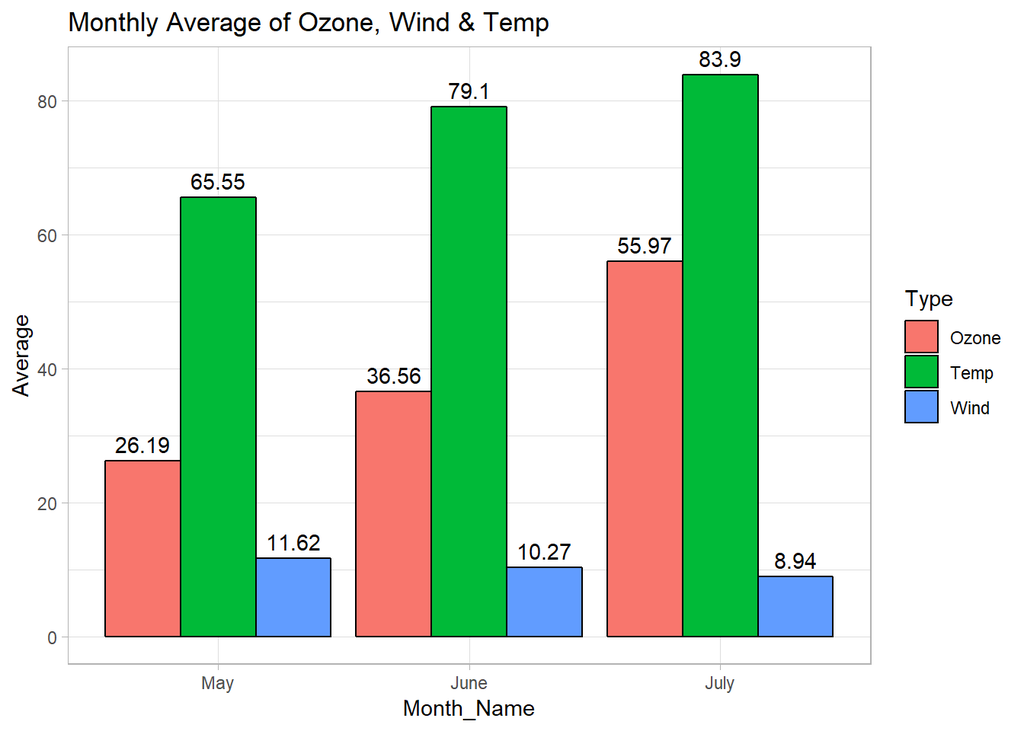

```r
# Plot the data to get Bar Plots for 3 different Types in 3 Different Months
ggplot(data = data_month_avg_tidy, aes(x = Month_Name, y = Average, fill = Type)) +
  geom_col(position="dodge", colour = "black") +
  geom_text(aes(label=round(Average,2)), position=position_dodge(width=0.9), vjust=-0.5) +
  scale_x_discrete(limits = c("May", "June", "July")) +
  labs(title = "Monthly Average of Ozone, Wind & Temp") +
  theme_light()
```

#### Observations:

- We have found the Monthly Average for Ozone and Temperature has increased significantly assuming the missing values for Ozone is replaced by its 3 Months average.
- On the other hand the Average Wind has decreased slightly for the 3 Months period.

### Part II

#### Diverging bar chart to compare Ozone and Temperature values with the 3 Months Average Value -

We will first prepare the data to get the deviation of the data from the 3 months average -

```r
# Get the deviation from the Average Value of 3 Month Period for Ozone and Temperature
# Also added a Row_Number Column to get the day Values in X Axis
data_dev_from_avg <- mutate(data,
                        Ozone_Dev = Ozone-mean(Ozone,na.rm = TRUE),
                        Ozone_Dev_Pos = ifelse((Ozone-mean(Ozone,na.rm = TRUE))>0,TRUE,FALSE),
                        Temp_Dev = Temp-mean(Temp,na.rm = TRUE),
                        Temp_Dev_Pos = ifelse((Temp-mean(Temp,na.rm = TRUE))>0,TRUE,FALSE),
                        id = row_number()
                        )
# Check The Data
print(head(data_dev_from_avg))
```

```
##      Ozone Wind Temp Month Day Month_Name  Ozone_Dev Ozone_Dev_Pos
## 1 41.00000  7.4   67     5   1        May   1.393443          TRUE
## 2 36.00000  8.0   72     5   2        May  -3.606557         FALSE
## 3 12.00000 12.6   74     5   3        May -27.606557         FALSE
## 4 18.00000 11.5   62     5   4        May -21.606557         FALSE
## 5 39.60656 14.3   56     5   5        May   0.000000         FALSE
## 6 28.00000 14.9   66     5   6        May -11.606557         FALSE
##     Temp_Dev Temp_Dev_Pos id
## 1  -9.152174        FALSE  1
## 2  -4.152174        FALSE  2
## 3  -2.152174        FALSE  3
## 4 -14.152174        FALSE  4
## 5 -20.152174        FALSE  5
## 6 -10.152174        FALSE  6
```

**Plot the Diverging Bar for Ozone**

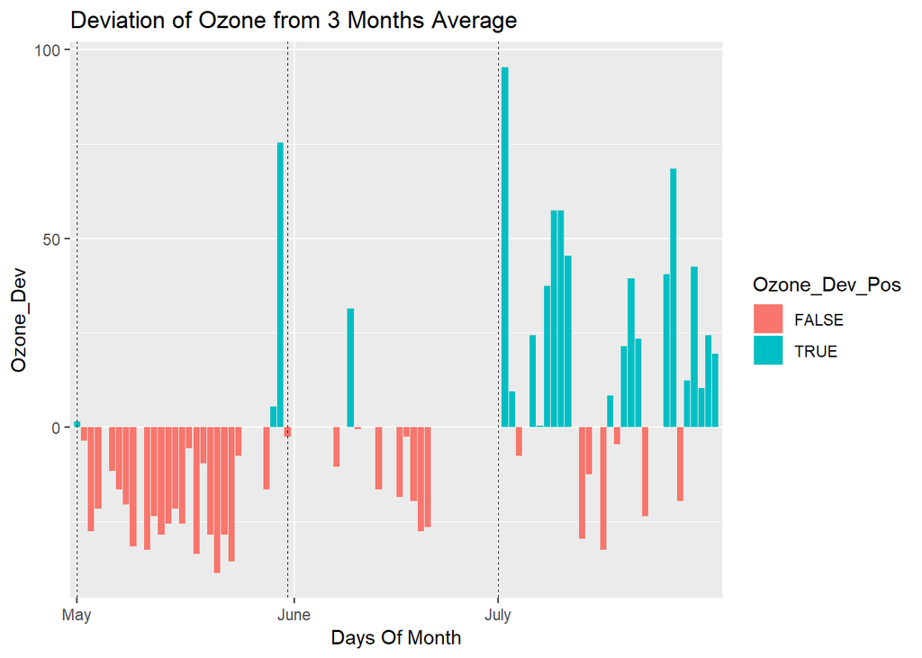

```r
# Plot the Diverging Bar for Ozone
ggplot(data_dev_from_avg, aes(x = id, y = Ozone_Dev, fill = Ozone_Dev_Pos)) +
  geom_col(position = "identity") +
  geom_vline(xintercept=1, linetype="dashed", size=.1) +
                  geom_vline(xintercept=31, linetype="dashed", size=.1) +
                  geom_vline(xintercept=61, linetype="dashed", size=.1) +
  scale_x_discrete(limits=c(1,32,61),
                   labels=c("May","June","July")) + # Define the Boundary for 3 months
  xlab("Days Of Month") +
  labs(title = "Deviation of Ozone from 3 Months Average")
```

**Plot the Diverging Bar for Temperature**

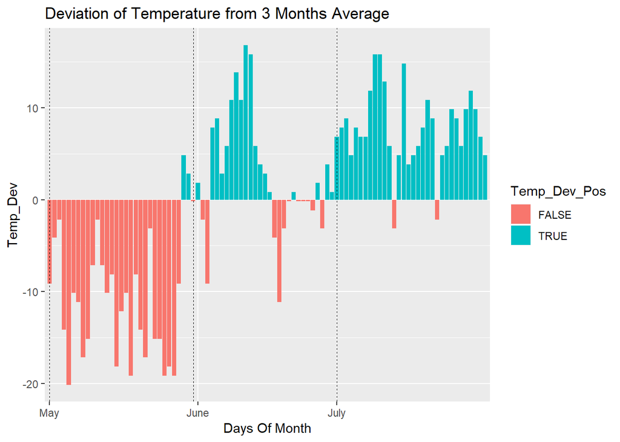

```r
# Plot the Diverging Bar for Temperature
ggplot(data_dev_from_avg, aes(x = id, y = Temp_Dev, fill = Temp_Dev_Pos)) +
  geom_col(position = "identity") +
  geom_vline(xintercept=1, linetype="dashed", size=.1) +
                  geom_vline(xintercept=31, linetype="dashed", size=.1) +
                  geom_vline(xintercept=61, linetype="dashed", size=.1) +
scale_x_discrete(limits=c(1,32,61),
                 labels=c("May","June","July")) + # Define the Boundary for 3 months
  xlab("Days Of Month") +
  labs(title = "Deviation of Temperature from 3 Months Average")
```

### Part III

#### A slope chart to display the changes in Ozone, Temp and Wind for the 3 Month -

To create the slope chart we first have to create the data in proper format -

```r
# Calculate and append 3 Month Max Value to the Tidy dataset
data_month_avg_tidy$Max3Month <- ifelse(data_month_avg_tidy$Type=="Ozone",max(data$Ozone),
                                        ifelse(data_month_avg_tidy$Type=="Wind",
                                               max(data$Wind),max(data$Temp)))

# Add a computed Column to calculate - average for the month/3 month maximum value
data_month_avg_tidy$Avg_Max <- data_month_avg_tidy$Average/data_month_avg_tidy$Max3Month

# Check The Data
print(head(data_month_avg_tidy))
```

```
## # A tibble: 6 x 5
##   Month_Name Type  Average Max3Month Avg_Max
##   <chr>      <chr>   <dbl>     <dbl>   <dbl>
## 1 May        Ozone   26.2      135     0.194
## 2 June       Ozone   36.6      135     0.271
## 3 July       Ozone   56.0      135     0.415
## 4 May        Wind    11.6       20.7   0.561
## 5 June       Wind    10.3       20.7   0.496
## 6 July       Wind     8.94      20.7   0.432
```

```r
# Remove the Aerage and Max3Month Column
data_month_avg_tidy <- data_month_avg_tidy[,-c(3,4)]

# Untidy the data to get the Month in  Column Level
data_month_avg_untidy <- spread(data_month_avg_tidy, key = Month_Name, value = Avg_Max)

# re-arrange the columns
data_month_avg_untidy <- data_month_avg_untidy[,c(1,4,3,2)]

print(head(data_month_avg_untidy))
```

```
## # A tibble: 3 x 4
##   Type    May  June  July
##   <chr> <dbl> <dbl> <dbl>
## 1 Ozone 0.194 0.271 0.415
## 2 Temp  0.705 0.851 0.902
## 3 Wind  0.561 0.496 0.432
```

I have added a new column class with different color just to differentiate the three Type - Ozone, Wind and Temperature

```r
# Add class Color Names for 3 different Types to differentiate
data_month_avg_untidy$class <- ifelse(data_month_avg_untidy$Type=="Ozone","Green",
                                  ifelse(data_month_avg_untidy$Type=="Temp","Blue","Red"))

# Save in a separate dataframe
data_slope <- data_month_avg_untidy

# create a vector of labels for May Data
May_label <- paste(data_month_avg_untidy$Type,
                   round(data_month_avg_untidy$`May`,3),sep=", ")

# create a vector of labels for June Data
June_label <- paste(data_month_avg_untidy$Type,
                    round(data_month_avg_untidy$`June`,3),sep=", ")

# create a vector of labels for July Data
July_label <- paste(data_month_avg_untidy$Type,
                    round(data_month_avg_untidy$`July`,3),sep=", ")

print(head(data_slope))
```

```
## # A tibble: 3 x 5
##   Type    May  June  July class
##   <chr> <dbl> <dbl> <dbl> <chr>
## 1 Ozone 0.194 0.271 0.415 Green
## 2 Temp  0.705 0.851 0.902 Blue
## 3 Wind  0.561 0.496 0.432 Red
```

**Plot the slope Chart -**

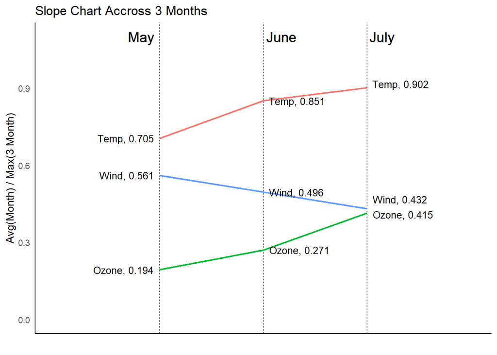

```r
# Plot the slope Chart
theme_set(theme_classic())

p <- ggplot(data_slope) +
                  geom_vline(xintercept=1, linetype="dashed", size=.1) +
                  geom_vline(xintercept=2, linetype="dashed", size=.1) +
                  geom_vline(xintercept=3, linetype="dashed", size=.1) +

                  labs(x="", y="Avg(Month) / Max(3 Month)") +  # Axis labels
                  xlim(0, 4) +
                  ylim(0.0,1.1)  # X and Y axis limits

p <- p + geom_segment(aes(x=1, xend=2, y=`May`, yend=`June`, col=class),
                      size=.75, show.legend=F) +
          geom_segment(aes(x=2, xend=3, y=`June`, yend=`July`, col=class),
                       size=.75, show.legend=F)

# Add texts
p <- p + geom_text(label=May_label, y=data_slope$`May`, x=rep(1, NROW(df)),
                   hjust=1.1, size=3.5) +
          geom_text(label=June_label, y=data_slope$`June`, x=rep(2, NROW(df)),
                    hjust=-0.1, size=3.5) +
          geom_text_repel(label=July_label, y=data_slope$`July`, x=rep(3, NROW(df)),
                    hjust=-0.1, vjust=0,size=3.5) +

          geom_text(label="May", x=1, y=1.1, hjust=1.2, size=5) +  # title of left line
          geom_text(label="June", x=2, y=1.1, hjust=-0.1, size=5) + # title of right line
          geom_text(label="July", x=3, y=1.1, hjust=-0.1, size=5)  # title of right line

# Minify theme
p + theme(panel.background = element_blank(),
           panel.grid = element_blank(),
           axis.ticks = element_blank(),
           axis.text.x = element_blank(),
           panel.border = element_blank()) +
  labs(title = "Slope Chart Accross 3 Months")
```

#### Observations:

- The above visualization shows the same trends of Temperature, Ozone and Wind with respect to three months as we have found in Part I
- As the data has been some what normalised the changes or the slope of the curves are more dominant than the graph we have generated in part I

### Part IV

#### Plot the distributions per month of temp, ozone and wind

I am visualizing the distribution considering the missing Values as replacing the missing values can change the actual distribution significantly as we have many numbers of missing Values

First I will prepare the data in correct format

```r
# Filter Out The May Data
data_May <- data_with_NA %>% filter(Month == 5) %>%
  gather(key = Type,value = Value, Ozone:Temp) %>%
  select(Type, Value, Month, Month_Name)

# Filter Out The June Data
data_June <- data_with_NA %>% filter(Month == 6) %>%
  gather(key = Type,value = Value, Ozone:Temp) %>%
  select(Type, Value, Month, Month_Name)

# Filter Out The July Data
data_July <- data_with_NA %>% filter(Month == 7) %>%
  gather(key = Type,value = Value, Ozone:Temp) %>%
  select(Type, Value, Month, Month_Name)

# Combine all the data for 3 Months
data_Month <- rbind(data_May,data_June,data_July)

print(head(data_Month))
```

```
##    Type Value Month Month_Name
## 1 Ozone    41     5        May
## 2 Ozone    36     5        May
## 3 Ozone    12     5        May
## 4 Ozone    18     5        May
## 5 Ozone    NA     5        May
## 6 Ozone    28     5        May
```

**Distribution with Bar Plot**

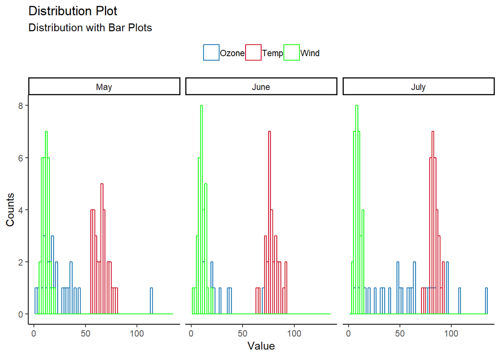

```r
ggplot(data_Month, aes(x=data_Month$Value,
                       color = data_Month$Type)) +
  geom_histogram(binwidth=2,fill=NA, alpha=0.8,
                 position="identity") +
  facet_wrap(~ factor(Month_Name,
                      levels= c("May","June","July"))) +
  theme_classic()+
  scale_colour_manual(values= c("#0571b0","#ca0020","green")) +
  theme(legend.position="top", legend.title = element_blank()) +
  labs(x="Value", y = "Counts", title = "Distribution Plot",
       subtitle = "Distribution with Bar Plots")
```

#### Observations:

- As we have not replaced the Missing Values for the Ozone it is more flat than the other values, but for Temperature and Wind the data shown a near normal pattern

**Distribution with Box Plot**

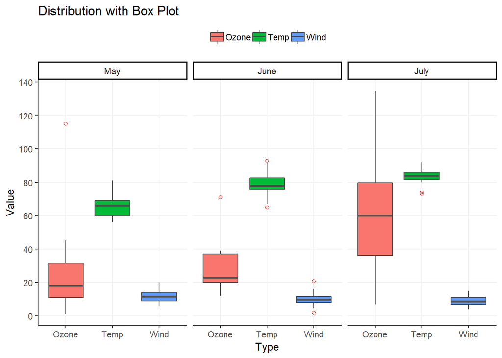

```r
# Plot the Box Plot
p <- ggplot(data_Month, aes(x = Type, y = Value)) +
      geom_boxplot(aes(fill = Type,color = Type), colour = "gray30",
                      outlier.colour = "red", outlier.shape = 1) +
    facet_wrap(~ factor(Month_Name,
                        levels= c("May","June","July"))) +
  scale_y_continuous(breaks = c(0,20,40,60,80,100,120,140)) +

  theme_classic() +
  theme(
    legend.position="top",legend.title = element_blank(),
    panel.grid.major.y =element_line(colour = "gray95"),
    panel.grid.major.x =element_line(colour = "gray95")
  ) +
  labs(title = "Distribution with Box Plot")

p
```

#### Observations:

- Here as we have plotted the data with the help of box plot, the overall trend can be found from the medium value
- We can also get an idea about the range of the data, we can see the Ozone data is more scattered in nature and has a long whisker compared to other.
- The wind data follows almost normalised in nature for all the three months
- We can also find the outliers highlighted in red circles

**Distribution with Strip Plot**

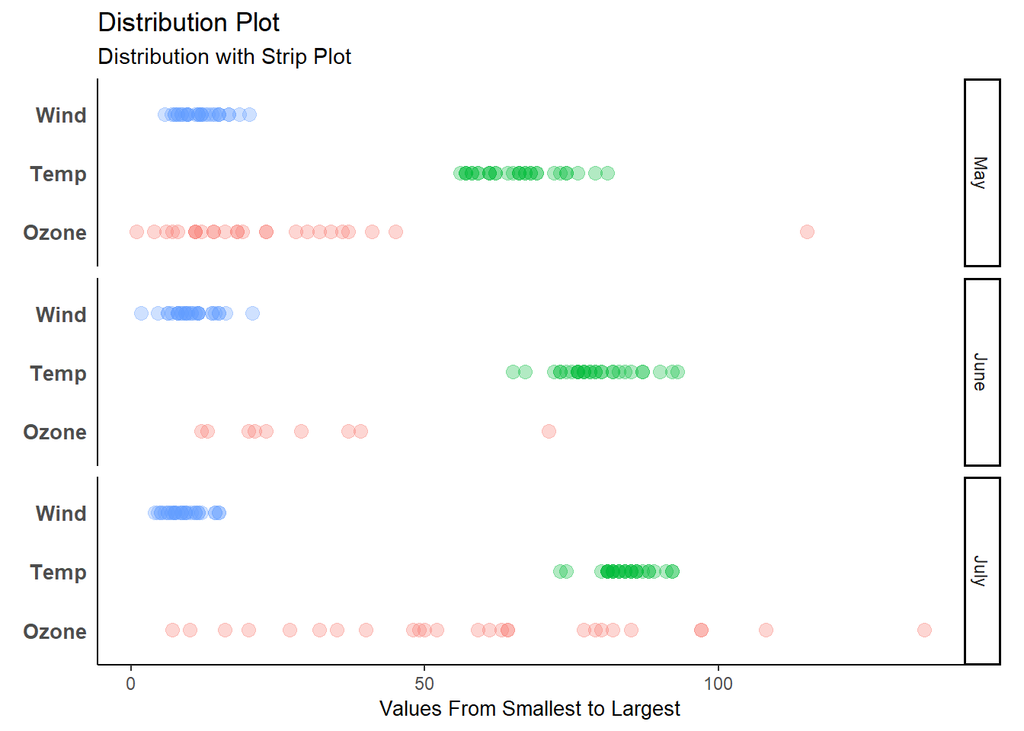

```r
ggplot(data_Month, aes(x=data_Month$Value, y=data_Month$Type)) +
  geom_point(aes(col=data_Month$Type), alpha=0.3,
             size = 3, show.legend=F) +
  coord_fixed(ratio=10)+
  facet_grid(factor(Month_Name, levels= c("May","June","July")) ~ .) +
  labs(x="Values From Smallest to Largest",
       title = "Distribution Plot",
       subtitle = "Distribution with Strip Plot") +

  theme_classic() +

theme(
  axis.text.y = element_text(size =10,face = "bold"),
  axis.ticks.y =  element_blank(),
  axis.title.y = element_blank(),
  axis.title.x = element_text(size = 10)
)
```

#### Observations:

- we have faceted the data with respect to Month
- we have ploted the Strip Plot and we are able to find the min and max values as well
- We are also get an idea about the data distribution.

### Part V

#### A plot showing the temporal aspect of the data.

To get the temporal aspect of the data I am plotting the data of the three months as a scatter points and then adding a regression line to get as overall trend of the average data.

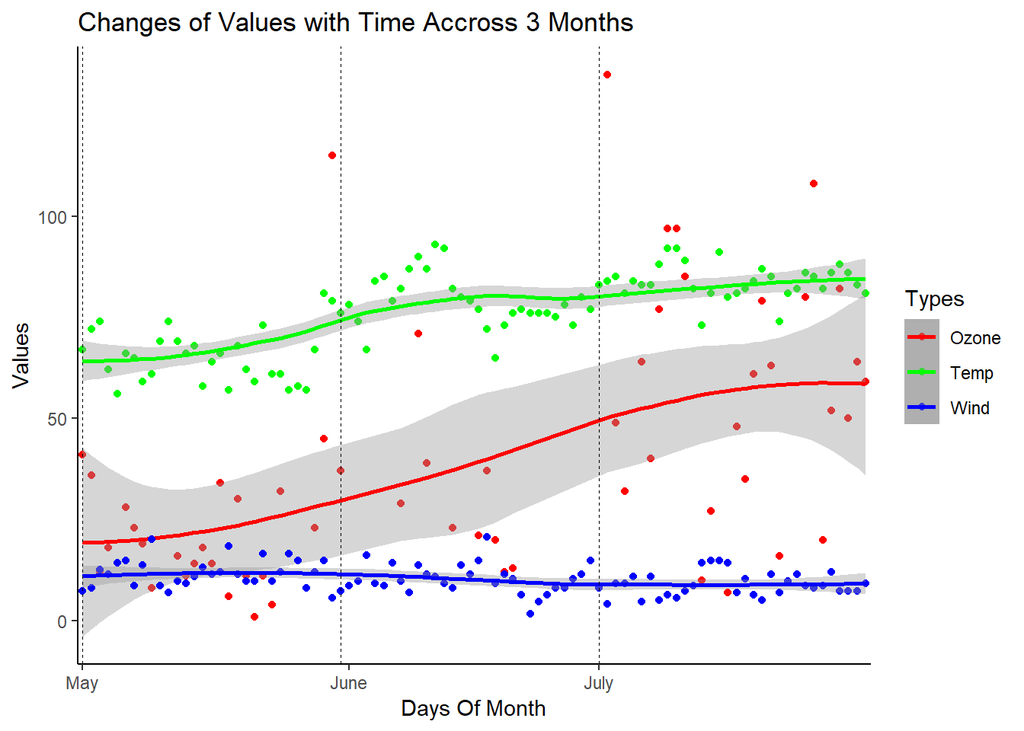

```r
data_with_ID <- mutate(data_with_NA,
                       dayId= row_number())

# Create a vector to add legends
cols <- c("Ozone"="red","Wind" = "blue", "Temp" = "green")

# Plot
ggplot(data= data_with_ID, aes(x= dayId )) +
  geom_point(aes(y = Ozone,color = "Ozone") ) +
  stat_smooth(aes(y = Ozone , color = "Ozone")) +
  geom_point(aes(y = Wind , color = "Wind")) +
  stat_smooth(aes(y = Wind , color = "Wind")) +
  geom_point(aes(y = Temp , color = "Temp")) +
  stat_smooth(aes(y = Temp , color = "Temp")) +
  scale_colour_manual(name="Types",values=cols) +
  geom_vline(xintercept=1, linetype="dashed", size=.1) +
                  geom_vline(xintercept=31, linetype="dashed", size=.1) +
                  geom_vline(xintercept=61, linetype="dashed", size=.1) +
  scale_x_discrete(limits=c(1,32,61), labels=c("May","June","July")) +
  labs(x="Days Of Month", y = "Values",
       title = "Changes of Values with Time Accross 3 Months")
```

#### Observations:

- Here also we have found the same trend as the Ozone and Temperature gradually increased and the wind decresed a little over the three months.
- As we have plotted the scatter plot we can also get an idea about the scatterness of the data